# A quick tour through Gluon

# Crearting Synthetic Data

```python
X = nd.random_normal(loc=0, scale=1, shape=(sample_size,2))
def fn(X, noise=.001):
    noise_term = noise * nd.random_normal(loc=0, scale=1, shape=(sample_size,))
    return (2 * X[:, 0] + 3.1 * X[:, 1] + math.pi) + noise
y = fn(X)
print(X.shape, y.shape)
```

```
(10000, 2) (10000,)
```

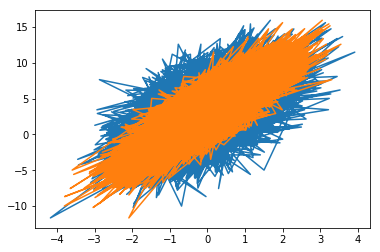

```python
plt.plot(X.asnumpy(),y.asnumpy())

plt.show()
```

```python
train_data = gluon.data.DataLoader(gluon.data.ArrayDataset(X,y), shuffle=True, batch_size=batch_size, last_batch='keep')
```

# Define a Network

```python
def define_net():
    net = gluon.nn.Sequential()
    with net.name_scope():
        net.add(gluon.nn.Dense(1))
    return net
```

```python
net = define_net()
net.collect_params()
```

```
sequential2_ (
  Parameter sequential2_dense0_weight (shape=(1, 0), dtype=float32)
  Parameter sequential2_dense0_bias (shape=(1,), dtype=float32)
)
```

# Initialzie Parameters

```python
net.collect_params().initialize(mx.init.Normal(), ctx=ctx, force_reinit=True)
```

## More initialization algorithms and parameters

for further information check the [API documentation](https://mxnet.incubator.apache.org/api/python/optimization/optimization.html)

| Function | Description | notes |
| --- | --- | --- |
| Uniform | Initializes weights with random values uniformly sampled from a given range. | A uniform distribution has constant probability |
| Normal | Initializes weights with random values sampled from a normal distribution with a mean of zero and standard deviation of sigma. | A normal distribution in a variate X with mean mu and variance sigma^2 is a statistic distribution with probability density function P(x) |
| Load | Initializes variables by loading data from file or dict. |  |
| Mixed | Initialize parameters using multiple initializers. |  |
| Zero | Initializes weights to zero. |  |
| One | Initializes weights to one. |  |
| Constant | Initializes the weights to a given value. |  |
| Orthogonal | Initialize weight as orthogonal matrix. | A Matrix A is orthagonal if $AA^T=I\ or\ A^{-1}=A^T$. Intentions is to use initialize conditions to benefit from depth independent finite delay in learning |
| Xavier | Returns an initializer performing “Xavier” initialization for weights. | This initializer is designed to keep the scale of gradients roughly the same in all layers. Randomizarion can be Uniform or Average |
| MSRAPrelu | Initialize the weight according to a MSRA paper. | [paper](https://arxiv.org/pdf/1502.01852.pdf) |
| Bilinear | Initialize weight for upsampling layers. |  |
| FusedRNN | Initialize parameters for fused rnn layers. | [1] |
| LSTMBias | Initialize all biases of an LSTMCell to 0.0 except for the forget gate whose bias is set to custom value. |  |

```python
net.collect_params()
```

```
sequential2_ (
  Parameter sequential2_dense0_weight (shape=(1, 0), dtype=float32)
  Parameter sequential2_dense0_bias (shape=(1,), dtype=float32)
)
```

```python
some_data = nd.array([[1,2]], ctx=ctx)
print(some_data.shape, net(some_data))
```

```
(1, 2)
[[ 0.00245928]]
<NDArray 1x1 @gpu(0)>
```

# Defining loss function

```python
loss_fn = gluon.loss.L2Loss()
```

## Further loss functions

[output not shown]

[output not shown]

[output not shown]

# Optimization

Gluon Trainer applies and optimizer and set parameters for that optimizer.

```python
trainer = gluon.Trainer(net.collect_params(), 'sgd', {'learning_rate': 0.001, 'momentum': .9})
```

ref: [2][3][4][5]

# Further optimization algorithms

Gradient Descent's goal is to minimize the objective fucnction $J(\theta)$ parameterized by a model's prameters $\theta$ through updating the parameters in the opposite direction of the gradient of the objective function. learning rate $\eta$ determines the stize of the step we are taking in the direction of a local minima.

[output not shown]

[output not shown]

for further information please check [MXNet documentation](https://mxnet.incubator.apache.org/api/python/optimization/optimization.html).

# Training Loop

```python
epochs = 2
for e in range(epochs):
    for i, (data, label) in enumerate(train_data):
        data = data.as_in_context(ctx)
        label = label.as_in_context(ctx)
        with autograd.record():
            y_hat = net(data)
            loss = loss_fn(y_hat, label)
        autograd.backward(loss)
        trainer.step(batch_size=batch_size)

    print("epoch: {}".format(e))
```

```
epoch: 0
epoch: 1
```

# Evaluation Metrics

```
epoch: 0; batch: 0; RMSE: 4.797231674194336
epoch: 0; batch: 100; RMSE: 4.823262311444424
epoch: 0; batch: 200; RMSE: 4.796083604518454
epoch: 0; batch: 300; RMSE: 4.80735121137676
epoch: 0; batch: 400; RMSE: 4.807119855262395
epoch: 0; batch: 500; RMSE: 4.790964190831441
epoch: 0; batch: 600; RMSE: 4.75370117035166
epoch: 0; batch: 700; RMSE: 4.755704509038558
epoch: 0; batch: 800; RMSE: 4.767971026019359
epoch: 0; batch: 900; RMSE: 4.757177492886881
epoch: 1; batch: 0; RMSE: 6.265623569488525
epoch: 1; batch: 100; RMSE: 4.879797260359962
epoch: 1; batch: 200; RMSE: 4.780074592846543
epoch: 1; batch: 300; RMSE: 4.739668083349335
epoch: 1; batch: 400; RMSE: 4.726510347570862
epoch: 1; batch: 500; RMSE: 4.76146391147149
epoch: 1; batch: 600; RMSE: 4.761130930976741
epoch: 1; batch: 700; RMSE: 4.764745098547997
epoch: 1; batch: 800; RMSE: 4.753533680489596
epoch: 1; batch: 900; RMSE: 4.758493993311426
```

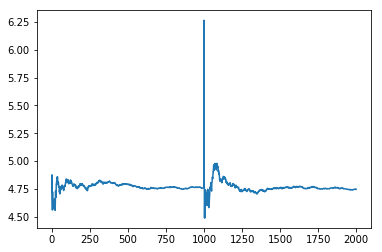

```python
epochs = 2
log_interval = 100
metrics = mx.metric.RMSE()
log = []
for e in range(epochs):
    metrics.reset()
    for i, (data, label) in enumerate(train_data):
        data = data.as_in_context(ctx)
        label = label.as_in_context(ctx)
        with autograd.record():
            y_hat = net(data)
            loss = loss_fn(y_hat, label)
        autograd.backward(loss)
        trainer.step(batch_size=batch_size)
        metrics.update(labels=loss, preds=y_hat)
        log.append(metrics.get()[1])
        if not(i % log_interval):
            print("epoch: {}; batch: {}; RMSE: {}".format(e,i,metrics.get()[1]))
plt.plot(log)
plt.show()
```

## More supported Evaluation Metrics

[output not shown]

## Using multiple metrics

```python
epochs = 2
log_interval = 100
eval_fn = lambda x, y: ((x + y).mean())
custom_metric = mx.metric.CustomMetric(feval=eval_fn, name='Nonsensical')
child_metrics = [mx.metric.RMSE(), mx.metric.Accuracy(), mx.metric.Perplexity(ignore_label=None), custom_metric]
metrics = mx.metric.CompositeEvalMetric()
for c in child_metrics:
    metrics.add(c)

log = []
for e in range(epochs):
    metrics.reset()
    for i, (data, label) in enumerate(train_data):
        data = data.as_in_context(ctx)
        label = label.as_in_context(ctx)
        with autograd.record():
            y_hat = net(data)
            loss = loss_fn(y_hat, label)
        autograd.backward(loss)
        trainer.step(batch_size=batch_size)
        metrics.update(labels=loss, preds=y_hat)
        log.append(metrics.get())

        if not(i % log_interval):
            print("epoch: {}; batch: {}; RMSE: {}".format(e,i,metrics.get_name_value()))
```

```
epoch: 0; batch: 0; RMSE: [('rmse', 4.3657245635986328), ('accuracy', 1.0), ('perplexity', 3.276986972323656), ('Nonsensical', 3.5193841457366943)]
epoch: 0; batch: 100; RMSE: [('rmse', 4.8817102602212739), ('accuracy', 1.0), ('perplexity', 28.200619456904597), ('Nonsensical', 3.323296484085593)]
epoch: 0; batch: 200; RMSE: [('rmse', 4.7642668017107459), ('accuracy', 1.0), ('perplexity', 25.91258486783947), ('Nonsensical', 3.2509262471353235)]
epoch: 0; batch: 300; RMSE: [('rmse', 4.6829357242267395), ('accuracy', 1.0), ('perplexity', 30.197751950537988), ('Nonsensical', 3.1656336900205706)]
epoch: 0; batch: 400; RMSE: [('rmse', 4.6740798058355244), ('accuracy', 1.0), ('perplexity', 29.661004416946568), ('Nonsensical', 3.1558677593520157)]
epoch: 0; batch: 500; RMSE: [('rmse', 4.6707300383173775), ('accuracy', 1.0), ('perplexity', 33.44960152325766), ('Nonsensical', 3.145690734871847)]
epoch: 0; batch: 600; RMSE: [('rmse', 4.7257885155384232), ('accuracy', 1.0), ('perplexity', 31.496872882900387), ('Nonsensical', 3.1877409523715592)]
epoch: 0; batch: 700; RMSE: [('rmse', 4.7411036484591804), ('accuracy', 1.0), ('perplexity', 29.7007893229819), ('Nonsensical', 3.2105942364681126)]
epoch: 0; batch: 800; RMSE: [('rmse', 4.7357163396518622), ('accuracy', 1.0), ('perplexity', 30.991649078845892), ('Nonsensical', 3.1937683017438419)]
epoch: 0; batch: 900; RMSE: [('rmse', 4.7412616706450166), ('accuracy', 1.0), ('perplexity', 31.522191516040227), ('Nonsensical', 3.1898617124253188)]
epoch: 1; batch: 0; RMSE: [('rmse', 5.6357660293579102), ('accuracy', 1.0), ('perplexity', 0.2333197224720777), ('Nonsensical', 4.9820442199707031)]
epoch: 1; batch: 100; RMSE: [('rmse', 4.7894600405551415), ('accuracy', 1.0), ('perplexity', 21.730890417916804), ('Nonsensical', 3.2675231189125835)]
epoch: 1; batch: 200; RMSE: [('rmse', 4.7568263711027834), ('accuracy', 1.0), ('perplexity', 28.311502174679458), ('Nonsensical', 3.1698451716063629)]
epoch: 1; batch: 300; RMSE: [('rmse', 4.7323198017487886), ('accuracy', 1.0), ('perplexity', 33.58970474185288), ('Nonsensical', 3.1182454056617033)]
epoch: 1; batch: 400; RMSE: [('rmse', 4.7314389673551718), ('accuracy', 1.0), ('perplexity', 33.91706556385746), ('Nonsensical', 3.1450091481134481)]
epoch: 1; batch: 500; RMSE: [('rmse', 4.7242445979051721), ('accuracy', 1.0), ('perplexity', 35.01630976326052), ('Nonsensical', 3.1351622194051743)]
epoch: 1; batch: 600; RMSE: [('rmse', 4.7407012604635685), ('accuracy', 1.0), ('perplexity', 33.900786536540444), ('Nonsensical', 3.1589176400677732)]
epoch: 1; batch: 700; RMSE: [('rmse', 4.7489290485708588), ('accuracy', 1.0), ('perplexity', 32.01610772458356), ('Nonsensical', 3.1944784164726308)]
epoch: 1; batch: 800; RMSE: [('rmse', 4.7548228238852284), ('accuracy', 1.0), ('perplexity', 31.79114304135661), ('Nonsensical', 3.1997500076685355)]
epoch: 1; batch: 900; RMSE: [('rmse', 4.767036127065051), ('accuracy', 1.0), ('perplexity', 32.44080851489383), ('Nonsensical', 3.2065614014863968)]
```

# Plotting the results

```python
from gluoncv.utils import TrainingHistory
epochs = 2
log_interval = 100
eval_fn = lambda x, y: ((x + y).mean())
custom_metric = mx.metric.CustomMetric(feval=eval_fn, name='Nonsensical')
child_metrics = [mx.metric.RMSE(), mx.metric.Accuracy(), mx.metric.Perplexity(ignore_label=None), custom_metric]
metrics = mx.metric.CompositeEvalMetric()
ths = []

for c in child_metrics:
    metrics.add(c)
    ths.append(TrainingHistory([c.name, c.name+"_val"]))

log = []
for e in range(epochs):
    metrics.reset()
    for i, (data, label) in enumerate(train_data):
        data = data.as_in_context(ctx)
        label = label.as_in_context(ctx)
        with autograd.record():
            y_hat = net(data)
            loss = loss_fn(y_hat, label)
        autograd.backward(loss)
        trainer.step(batch_size=batch_size)
        metrics.update(labels=loss, preds=y_hat)
        log.append(metrics.get())
        for j in range(len(metrics.get()[0])):
            val = metrics.get()[1][j]
            ths[j].update([val, val/2])

        if not(i % log_interval):
            print("epoch: {}; batch: {}; RMSE: {}".format(e,i,metrics.get_name_value()))
```

```
epoch: 0; batch: 0; RMSE: [('rmse', 3.9852550029754639), ('accuracy', 1.0), ('perplexity', 45.49033794401938), ('Nonsensical', 2.9216949939727783)]
epoch: 0; batch: 100; RMSE: [('rmse', 4.7905478217814226), ('accuracy', 1.0), ('perplexity', 41.80278565256689), ('Nonsensical', 3.1357937123220747)]
epoch: 0; batch: 200; RMSE: [('rmse', 4.7555478615547297), ('accuracy', 1.0), ('perplexity', 33.498222512961725), ('Nonsensical', 3.212168287207831)]
epoch: 0; batch: 300; RMSE: [('rmse', 4.7140792152810338), ('accuracy', 1.0), ('perplexity', 31.735004196731218), ('Nonsensical', 3.1780128445340154)]
epoch: 0; batch: 400; RMSE: [('rmse', 4.7118840378121547), ('accuracy', 1.0), ('perplexity', 32.09808434260283), ('Nonsensical', 3.1719642203496283)]
epoch: 0; batch: 500; RMSE: [('rmse', 4.7431857883335349), ('accuracy', 1.0), ('perplexity', 30.366661597369028), ('Nonsensical', 3.1964689864964781)]
epoch: 0; batch: 600; RMSE: [('rmse', 4.715266219193051), ('accuracy', 1.0), ('perplexity', 29.43009267075859), ('Nonsensical', 3.1877132740472995)]
epoch: 0; batch: 700; RMSE: [('rmse', 4.7125444175853541), ('accuracy', 1.0), ('perplexity', 30.765149845662084), ('Nonsensical', 3.1812047358926456)]
epoch: 0; batch: 800; RMSE: [('rmse', 4.7096425777070978), ('accuracy', 1.0), ('perplexity', 31.97705928402336), ('Nonsensical', 3.1677776165632126)]
epoch: 0; batch: 900; RMSE: [('rmse', 4.7253482594474177), ('accuracy', 1.0), ('perplexity', 31.926462893422563), ('Nonsensical', 3.1837933987180613)]
epoch: 1; batch: 0; RMSE: [('rmse', 6.4447674751281738), ('accuracy', 1.0), ('perplexity', 27.622261312289197), ('Nonsensical', 4.0547013282775879)]
epoch: 1; batch: 100; RMSE: [('rmse', 4.7876463998662366), ('accuracy', 1.0), ('perplexity', 35.955954951361385), ('Nonsensical', 3.1820864948158216)]
epoch: 1; batch: 200; RMSE: [('rmse', 4.7035737286752726), ('accuracy', 1.0), ('perplexity', 32.086252259045615), ('Nonsensical', 3.155315309818556)]
epoch: 1; batch: 300; RMSE: [('rmse', 4.7327457420849717), ('accuracy', 1.0), ('perplexity', 32.52878741412676), ('Nonsensical', 3.1758833677442961)]
epoch: 1; batch: 400; RMSE: [('rmse', 4.7568223592349117), ('accuracy', 1.0), ('perplexity', 36.14880989440005), ('Nonsensical', 3.1740269887904424)]
epoch: 1; batch: 500; RMSE: [('rmse', 4.7360895534237466), ('accuracy', 1.0), ('perplexity', 35.958283864776135), ('Nonsensical', 3.1579917334614995)]
epoch: 1; batch: 600; RMSE: [('rmse', 4.7392029280273764), ('accuracy', 1.0), ('perplexity', 31.93322536646495), ('Nonsensical', 3.1931528165105871)]
epoch: 1; batch: 700; RMSE: [('rmse', 4.7564269868861588), ('accuracy', 1.0), ('perplexity', 29.84018940896536), ('Nonsensical', 3.2204235877772627)]
epoch: 1; batch: 800; RMSE: [('rmse', 4.7381346608220269), ('accuracy', 1.0), ('perplexity', 32.30469218252686), ('Nonsensical', 3.1965281242055914)]
epoch: 1; batch: 900; RMSE: [('rmse', 4.7470143385123995), ('accuracy', 1.0), ('perplexity', 33.22765392587356), ('Nonsensical', 3.1913612733381105)]
```

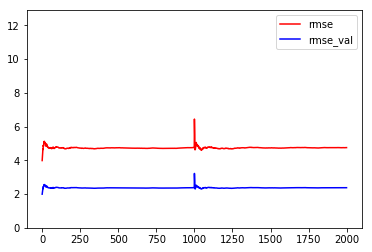

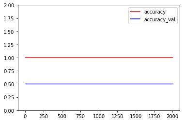

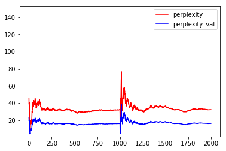

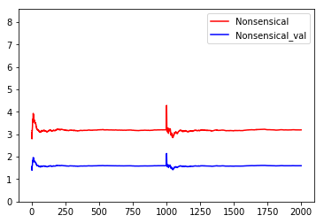

```python
min_val, max_val = 0, 0
for th in ths:
    min_val =  nd.array(th.history[th.labels[0]]).min().asscalar()
    min_val = min(min_val, nd.array(th.history[th.labels[1]]).min().asscalar()) // 2
    max_val =  nd.array(th.history[th.labels[0]]).max().asscalar()
    max_val =  max(max_val, nd.array(th.history[th.labels[1]]).max().asscalar()) * 2
    th.plot(labels=th.labels, y_lim=(min_val, max_val), colors=('red', 'blue'))
```

# Refrences:

1. EcoRNN: Fused LSTM RNN Implementation with Data Layout Optimization Zheng et al.: arXiv:1805.08899
2. Sebastian Ruder: http://ruder.io/optimizing-gradient-descent/
3. Asynchronous Stochastic Gradient Descent with Delay Compensation; Zheng et al.: arXiv:1609.08326 [cs.LG]
4. Compressed Optimisation for Non-Convex Problems. Anandkumar et al.: arXiv:1802.04434 [cs.LG]
5. Follow the Moving Leader in Deep Learning. Zheng et al.: [paper](http://proceedings.mlr.press/v70/zheng17a/zheng17a.pdf)
6. Accurate, Large Minibatch SGD: Training ImageNet in 1 Hour, He et al.: arXiv:1706.02677 [cs.CV]
7. [Twards Data Science Blog](https://towardsdatascience.com/deep-learning-at-scale-accurate-large-mini-batch-sgd-8207d54bfe02). This is an intuitive version of [6].
8. [MAE and RMSE — Which Metric is Better?](https://medium.com/human-in-a-machine-world/mae-and-rmse-which-metric-is-better-e60ac3bde13d)